# Proyecto Final Econometría - Regresión Lineal Simple y Múltiple

Valeria Acosta - A00818610

2026-03-17

# Carga de Librerías

```r
library(quantmod)
library(readxl)
library(car)
library(lmtest)
library(sandwich)
library(ggcorrplot)
library(ggplot2)
library(tidyr)
```

# Descripción del Portafolio

Variable dependiente - NVDA (NVIDIA)  
Variables independientes - AAPL, META, AMD, INTC, PLTR, LMT, GD, JPM, JNJ, XOM

- Tecnología/Semiconductores: AAPL, META, AMD, INTC, PLTR
- Defensa: LMT, GD
- Bancos: JPM
- Energía: XOM
- Salud: JNJ

Se quitó TSM que se usó en la Tarea 7 y se agregaron META, AMD, INTC que son acciones que tengo en mi portafolio de HowTheMarketWorks.

El análisis se hace en dos timeframes: datos diarios a 5 años (Marzo 2021 - Marzo 2026) y datos intradiarios de 5 minutos (última semana de trading), para verificar que las relaciones del portafolio son robustas y no dependen de la frecuencia de muestreo.

# Parte 1: Regresiones con datos diarios (5 Años)

## Carga de Datos

### Desde Excel de Refinitiv

Los datos principales vienen del archivo descargado de Refinitiv con precios de cierre diarios para las 11 acciones

```r
precios_ref <- read_excel("DAILYPRICESALL5Y.xlsx", sheet = "Table Data")

# Limpiar nombres (Refinitiv agrega .O al final)
colnames(precios_ref) <- gsub("\\.O$", "", colnames(precios_ref))

precios_ref$Date <- as.Date(precios_ref$Date)
precios_ref <- precios_ref[order(precios_ref$Date), ]

cat("Datos Refinitiv:", nrow(precios_ref), "observaciones\n")
```

```
## Datos Refinitiv: 1256 observaciones
```

```r
cat("Periodo:", as.character(min(precios_ref$Date)), "a", as.character(max(precios_ref$Date)), "\n")
```

```
## Periodo: 2021-03-15 a 2026-03-13
```

```r
cat("Acciones:", paste(colnames(precios_ref)[-1], collapse = ", "), "\n")
```

```
## Acciones: NVDA, AAPL, META, AMD, INTC, PLTR, LMT, GD, JPM, JNJ, XOM
```

```r
head(precios_ref)
```

```
## # A tibble: 6 × 12
##   Date        NVDA  AAPL  META   AMD  INTC  PLTR   LMT    GD   JPM   JNJ   XOM
##   <date>     <dbl> <dbl> <dbl> <dbl> <dbl> <dbl> <dbl> <dbl> <dbl> <dbl> <dbl>
## 1 2021-03-15  13.2  124.  274.  82.5  63.8  26.8  346.  177.  155.  160.  60.4
## 2 2021-03-16  13.3  126.  279.  82.8  64.8  25.6  347.  175.  154.  161.  59.1
## 3 2021-03-17  13.3  125.  284.  82.6  65.8  25.2  351.  178.  155.  161.  59.4
## 4 2021-03-18  12.7  121.  279.  78.1  63.7  24.0  358.  179.  158.  160.  56.8
## 5 2021-03-19  12.8  120.  290.  79.1  63.8  24.3  355.  178.  155.  160.  56.5
## 6 2021-03-22  13.2  123.  294.  80.3  65.6  24.2  358.  177.  151.  160.  55.9
```

### Desde Yahoo Finance con quantmod

Para comparar contra otra fuente, también descargamos los mismos datos con quantmod como hemos hecho en las tareas del curso

```r
inicio <- as.character(min(precios_ref$Date))
fin    <- as.character(max(precios_ref$Date))

getSymbols("NVDA", from = inicio, to = fin, src = "yahoo")
```

```
## [1] "NVDA"
```

```r
getSymbols("AAPL", from = inicio, to = fin, src = "yahoo")
```

```
## [1] "AAPL"
```

```r
getSymbols("META", from = inicio, to = fin, src = "yahoo")
```

```
## [1] "META"
```

```r
getSymbols("AMD",  from = inicio, to = fin, src = "yahoo")
```

```
## [1] "AMD"
```

```r
getSymbols("INTC", from = inicio, to = fin, src = "yahoo")
```

```
## [1] "INTC"
```

```r
getSymbols("PLTR", from = inicio, to = fin, src = "yahoo")
```

```
## [1] "PLTR"
```

```r
getSymbols("LMT",  from = inicio, to = fin, src = "yahoo")
```

```
## [1] "LMT"
```

```r
getSymbols("GD",   from = inicio, to = fin, src = "yahoo")
```

```
## [1] "GD"
```

```r
getSymbols("JPM",  from = inicio, to = fin, src = "yahoo")
```

```
## [1] "JPM"
```

```r
getSymbols("JNJ",  from = inicio, to = fin, src = "yahoo")
```

```
## [1] "JNJ"
```

```r
getSymbols("XOM",  from = inicio, to = fin, src = "yahoo")
```

```
## [1] "XOM"
```

```r
precios_yahoo <- merge(Ad(NVDA), Ad(AAPL), Ad(META), Ad(AMD), Ad(INTC),
                       Ad(PLTR), Ad(LMT), Ad(GD), Ad(JPM), Ad(JNJ), Ad(XOM))
colnames(precios_yahoo) <- c("NVDA", "AAPL", "META", "AMD", "INTC",
                              "PLTR", "LMT", "GD", "JPM", "JNJ", "XOM")
precios_yahoo <- na.omit(precios_yahoo)

cat("Datos Yahoo:", nrow(precios_yahoo), "observaciones\n")
```

```
## Datos Yahoo: 1255 observaciones
```

```r
cat("Datos Refinitiv:", nrow(precios_ref), "observaciones\n")
```

```
## Datos Refinitiv: 1256 observaciones
```

## Preparación de datos

Calculamos retornos porcentuales diarios que es lo que usan Bloomberg y Refinitiv para sus regresiones.

```r
precios_xts <- xts(precios_ref[, -1], order.by = precios_ref$Date)
precios_xts <- na.omit(precios_xts)

retornos <- data.frame(na.omit(ROC(precios_xts, type = "discrete") * 100))
colnames(retornos) <- c("NVDA", "AAPL", "META", "AMD", "INTC",
                         "PLTR", "LMT", "GD", "JPM", "JNJ", "XOM")

cat("Observaciones:", nrow(retornos), "\n")
```

```
## Observaciones: 1255
```

```r
cat("Periodo:", as.character(index(precios_xts)[2]), "a",
    as.character(index(precios_xts)[nrow(precios_xts)]))
```

```
## Periodo: 2021-03-16 a 2026-03-13
```

## Análisis Exploratorio

### Estadísticas descriptivas

```r
summary(retornos)
```

```
##       NVDA               AAPL               META                AMD
##  Min.   :-16.9682   Min.   :-9.24561   Min.   :-26.39009   Min.   :-17.3144
##  1st Qu.: -1.5830   1st Qu.:-0.77630   1st Qu.: -1.15708   1st Qu.: -1.7509
##  Median :  0.2814   Median : 0.09884   Median :  0.07014   Median :  0.0000
##  Mean   :  0.2615   Mean   : 0.07136   Mean   :  0.10246   Mean   :  0.1239
##  3rd Qu.:  2.0427   3rd Qu.: 0.95813   3rd Qu.:  1.38675   3rd Qu.:  1.9014
##  Max.   : 24.3615   Max.   :15.32885   Max.   : 23.28239   Max.   : 23.8205
##       INTC                PLTR               LMT                  GD
##  Min.   :-26.05852   Min.   :-21.3080   Min.   :-11.80347   Min.   :-7.27320
##  1st Qu.: -1.46288   1st Qu.: -1.9524   1st Qu.: -0.57851   1st Qu.:-0.60402
##  Median : -0.04083   Median :  0.1116   Median :  0.06504   Median : 0.07909
##  Mean   :  0.01931   Mean   :  0.2216   Mean   :  0.06032   Mean   : 0.06342
##  3rd Qu.:  1.39106   3rd Qu.:  2.1716   3rd Qu.:  0.73082   3rd Qu.: 0.75468
##  Max.   : 22.77108   Max.   : 30.8014   Max.   :  8.93370   Max.   : 8.42957
##       JPM                JNJ                XOM
##  Min.   :-8.05020   Min.   :-7.59165   Min.   :-7.88527
##  1st Qu.:-0.74733   1st Qu.:-0.53296   1st Qu.:-0.89292
##  Median : 0.09602   Median : 0.03706   Median : 0.08459
##  Mean   : 0.05991   Mean   : 0.03883   Mean   : 0.08963
##  3rd Qu.: 0.91218   3rd Qu.: 0.59441   3rd Qu.: 1.14018
##  Max.   :11.54454   Max.   : 6.19321   Max.   : 6.41127
```

```r
cat("Volatilidad diaria (desv. est. de retornos %):\n")
```

```
## Volatilidad diaria (desv. est. de retornos %):
```

```r
sort(sapply(retornos, sd), decreasing = TRUE)
```

```
##     PLTR      AMD     NVDA     INTC     META     AAPL      XOM      JPM
## 4.125493 3.356788 3.256112 3.025031 2.742943 1.732137 1.679949 1.537813
##      LMT       GD      JNJ
## 1.419858 1.257690 1.050665
```

### Precios normalizados

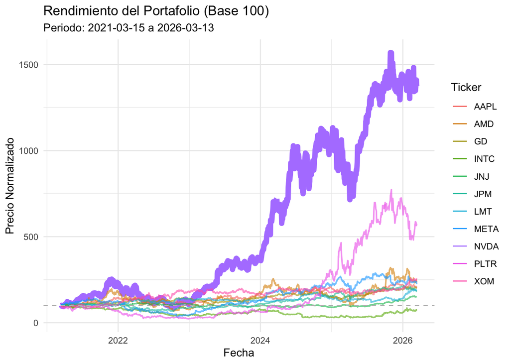

```r
precios_norm <- as.data.frame(lapply(precios_ref[, -1], function(x) x / x[1] * 100))
precios_norm$Date <- precios_ref$Date

precios_long <- pivot_longer(precios_norm, cols = -Date,
                              names_to = "Ticker", values_to = "Valor")

ggplot(precios_long, aes(x = Date, y = Valor, color = Ticker)) +
  geom_line(aes(linewidth = ifelse(Ticker == "NVDA", "dep", "indep"),
                alpha = ifelse(Ticker == "NVDA", "dep", "indep"))) +
  scale_linewidth_manual(values = c("dep" = 2.5, "indep" = 0.7), guide = "none") +
  scale_alpha_manual(values = c("dep" = 1, "indep" = 0.6), guide = "none") +
  geom_hline(yintercept = 100, linetype = "dashed", color = "gray") +
  labs(title = "Rendimiento del Portafolio (Base 100)",
       subtitle = paste("Periodo:", min(precios_norm$Date), "a", max(precios_norm$Date)),
       x = "Fecha", y = "Precio Normalizado") +
  theme_minimal()
```

La gráfica muestra la diferencia entre las acciones de crecimiento y defensivas del portafolio. NVDA se despega del resto a partir de mediados de 2023, que coincide con el lanzamiento de los chips AI y la explosión de demanda por infraestructura. PLTR tiene un comportamiento similar pero más tardado, con el periodo fuerte concentrado en 2024-2025. INTC es lo opuesta, ha perdido valor reflejando la pérdida de market share frente a NVDA y AMD en el segmento de data centers. Las defensivas (LMT, GD y JNJ muestran crecimientos del 50-100% en el periodo, que es poco comparado con tech pero con mucha menos volatilidad, exactamente lo que esperaría de empresas con contratos de largo plazo y dividendos estables.

### Matriz de Correlación

```r
cor_mat <- cor(retornos)
print(round(cor_mat, 3))
```

```
##        NVDA  AAPL  META    AMD  INTC   PLTR    LMT    GD   JPM    JNJ   XOM
## NVDA  1.000 0.508 0.493  0.687 0.370  0.488 -0.026 0.160 0.325 -0.100 0.088
## AAPL  0.508 1.000 0.475  0.479 0.359  0.376  0.088 0.291 0.368  0.144 0.200
## META  0.493 0.475 1.000  0.457 0.306  0.400  0.008 0.159 0.300  0.001 0.070
## AMD   0.687 0.479 0.457  1.000 0.426  0.454  0.029 0.186 0.305 -0.032 0.131
## INTC  0.370 0.359 0.306  0.426 1.000  0.284  0.067 0.179 0.302  0.077 0.164
## PLTR  0.488 0.376 0.400  0.454 0.284  1.000  0.025 0.172 0.314 -0.051 0.103
## LMT  -0.026 0.088 0.008  0.029 0.067  0.025  1.000 0.593 0.157  0.236 0.270
## GD    0.160 0.291 0.159  0.186 0.179  0.172  0.593 1.000 0.402  0.279 0.391
## JPM   0.325 0.368 0.300  0.305 0.302  0.314  0.157 0.402 1.000  0.180 0.334
## JNJ  -0.100 0.144 0.001 -0.032 0.077 -0.051  0.236 0.279 0.180  1.000 0.126
## XOM   0.088 0.200 0.070  0.131 0.164  0.103  0.270 0.391 0.334  0.126 1.000
```

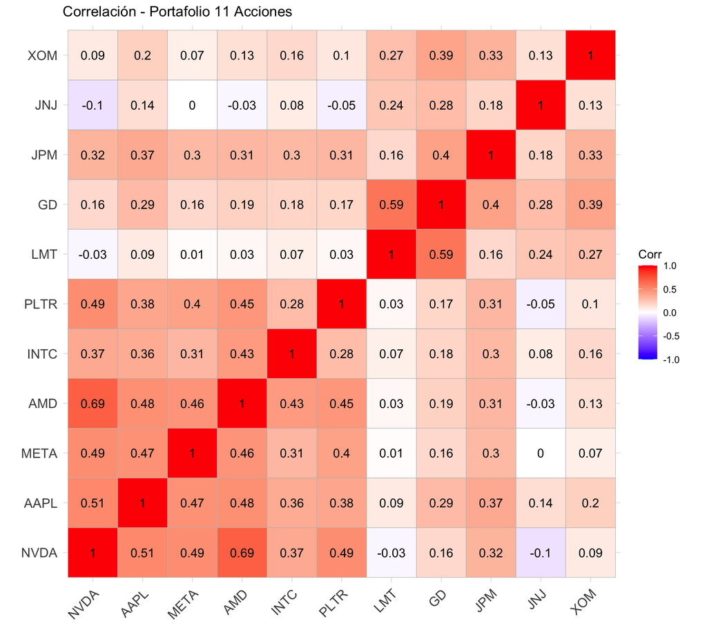

```r
ggcorrplot(cor_mat, lab = TRUE, title = "Correlación - Portafolio 11 Acciones")
```

```r
cat("Correlación de NVDA con cada acción:\n")
```

```
## Correlación de NVDA con cada acción:
```

```r
sort(cor_mat["NVDA", ], decreasing = TRUE)
```

```
##        NVDA         AMD        AAPL        META        PLTR        INTC
##  1.00000000  0.68671443  0.50768379  0.49300876  0.48784494  0.36955476
##         JPM          GD         XOM         LMT         JNJ
##  0.32485793  0.15958965  0.08842050 -0.02616871 -0.10001771
```

AMD tiene la correlación más fuerte con NVDA (0.69) . Esto se explica porque ambas compiten por los mismos clientes.. AAPL (0.51) y META (0.49) capturan el sentimiento general del sector tech, pero su correlación es menor porque tienen factores propios (iPhone para AAPL, advertising para META) que NVDA no tiene. PLTR (0.49) está al mismo nivel, ligada al tema AI pero desde el lado del software. INTC (0.37) se mueve en la misma dirección pero menos, Intel compite en semiconductores pero ha quedado abajo y el mercado ya no la ve bien. La correlación negativa con JNJ (-0.10) y casi cero con LMT (-0.03) es la evidencia más clara de que estas acciones ofrecen diversificación porque cuando los inversionistas rotan de acciones, JNJ sube mientras NVDA baja. El LMT-GD (0.59) se mueve por factores distintos (presupuesto de defensa, conflictos geopolíticos) que no afectan a semiconductores.

## Regresión Lineal Simple

### Selección del mejor predictor

Corremos una regresión simple de NVDA contra cada acción para ver cuál tiene mayor R2.

```r
tickers_indep <- c("AAPL", "META", "AMD", "INTC", "PLTR", "LMT", "GD", "JPM", "JNJ", "XOM")

resultados <- data.frame(Ticker = character(), R2 = numeric(), Beta = numeric(),
                          Alpha = numeric(), t_stat = numeric(), P_value = numeric())

for (t in tickers_indep) {
  f <- as.formula(paste("NVDA ~", t))
  m <- lm(f, data = retornos)
  s <- summary(m)
  resultados <- rbind(resultados, data.frame(
    Ticker = t,
    R2 = round(s$r.squared, 4),
    Beta = round(coef(m)[2], 4),
    Alpha = round(coef(m)[1], 4),
    t_stat = round(s$coefficients[2, 3], 2),
    P_value = s$coefficients[2, 4]
  ))
}

resultados <- resultados[order(-resultados$R2), ]
rownames(resultados) <- NULL
resultados
```

```
##    Ticker     R2    Beta  Alpha t_stat       P_value
## 1     AMD 0.4716  0.6661 0.1789  33.44 9.202481e-176
## 2    AAPL 0.2577  0.9544 0.1934  20.86  3.536928e-83
## 3    META 0.2431  0.5852 0.2015  20.06  7.794782e-78
## 4    PLTR 0.2380  0.3850 0.1761  19.78  5.139192e-76
## 5    INTC 0.1366  0.3978 0.2538  14.08  6.746982e-42
## 6     JPM 0.1055  0.6878 0.2203  12.16  3.114920e-32
## 7      GD 0.0255  0.4132 0.2353   5.72  1.312305e-08
## 8     JNJ 0.0100 -0.3100 0.2735  -3.56  3.872909e-04
## 9     XOM 0.0078  0.1714 0.2461   3.14  1.716175e-03
## 10    LMT 0.0007 -0.0600 0.2651  -0.93  3.542968e-01
```

*Interpretación:* AMD es el mejor predictor individual de NVDA con un R2 de 0.47, muy por encima del segundo (AAPL con 0.26). Esta diferencia de casi el doble en poder explicativo refleja que AMD y NVDA comparten los mismos factores fundamentales, demanda de GPUs, capex, ciclo de semiconductores,etc. AAPL y META capturan el sentimiento tech general pero no los factores específicos de semiconductores. Lo interesante es que PLTR (R2 = 0.24) tiene casi el mismo poder que META (R2 = 0.24). En el otro extremo, LMT tiene R2 de 0.0007 y ni siquiera es significativa (p = 0.35), el sector de defensa y los semiconductores se mueven por factores completamente independientes.

### Modelo de Regresión Simple

```r
mejor <- resultados$Ticker[1]
formula_simple <- as.formula(paste("NVDA ~", mejor))
reg_simple <- lm(formula_simple, data = retornos)
summary(reg_simple)
```

```
##
## Call:
## lm(formula = formula_simple, data = retornos)
##
## Residuals:
##      Min       1Q   Median       3Q      Max
## -17.0799  -1.3093  -0.0871   1.2223  16.7505
##
## Coefficients:
##             Estimate Std. Error t value Pr(>|t|)
## (Intercept)  0.17892    0.06689   2.675  0.00757 **
## AMD          0.66612    0.01992  33.440  < 2e-16 ***
## ---
## Signif. codes:  0 '***' 0.001 '**' 0.01 '*' 0.05 '.' 0.1 ' ' 1
##
## Residual standard error: 2.368 on 1253 degrees of freedom
## Multiple R-squared:  0.4716, Adjusted R-squared:  0.4712
## F-statistic:  1118 on 1 and 1253 DF,  p-value: < 2.2e-16
```

*Fórmula:* NVDA = 0.1789 + 0.6661 * AMD

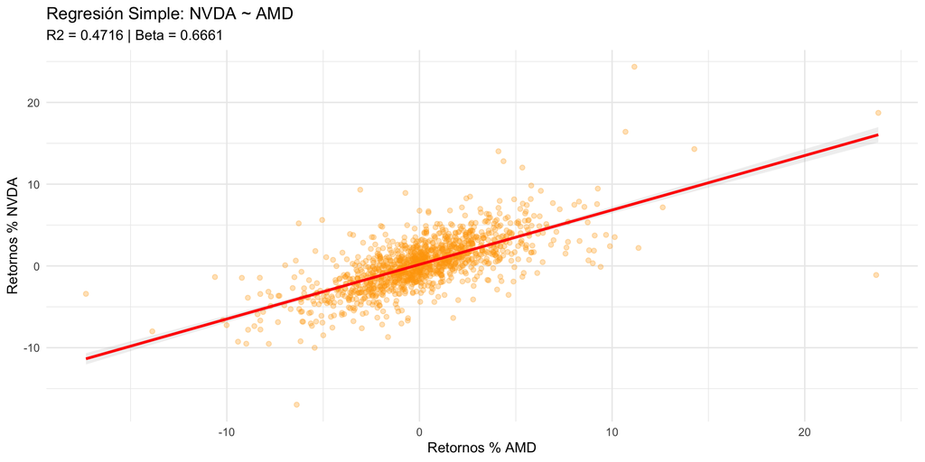

```r
ggplot(retornos, aes_string(x = mejor, y = "NVDA")) +
  geom_point(alpha = 0.3, size = 1.5, color = "orange") +
  geom_smooth(method = "lm", color = "red", se = TRUE, alpha = 0.15) +
  labs(title = paste("Regresión Simple: NVDA ~", mejor),
       subtitle = paste("R2 =", round(summary(reg_simple)$r.squared, 4),
                        "| Beta =", round(coef(reg_simple)[2], 4)),
       x = paste("Retornos %", mejor),
       y = "Retornos % NVDA") +
  theme_minimal()
```

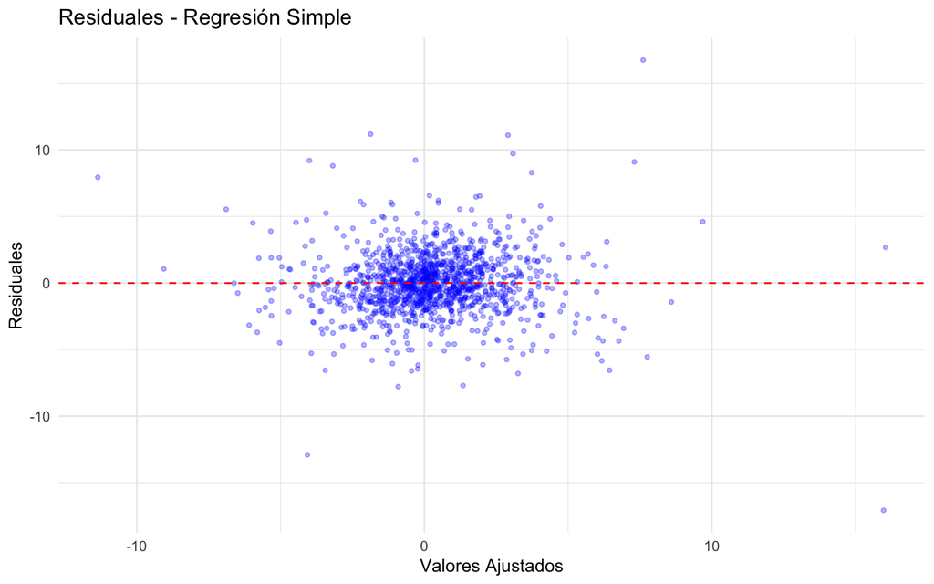

```r
ggplot(data.frame(fitted = fitted(reg_simple), residuals = resid(reg_simple)),
       aes(x = fitted, y = residuals)) +
  geom_point(alpha = 0.3, size = 1, color = "blue") +
  geom_hline(yintercept = 0, color = "red", linetype = "dashed") +
  labs(title = "Residuales - Regresión Simple",
       x = "Valores Ajustados", y = "Residuales") +
  theme_minimal()
```

*Interpretación:* Los residuales están centrados en cero sin un patrón, lo que valida la especificación lineal. Los outliers en ambas colas corresponden a días de earnings de NVDA o noticias (como restricciones de exportación a China o anuncios de nuevos chips) que mueven a NVDA de forma independiente a AMD. Estos eventos son impredecibles con otras acciones, y explican parte del 53% que el modelo no captura.

### Diagnóstico

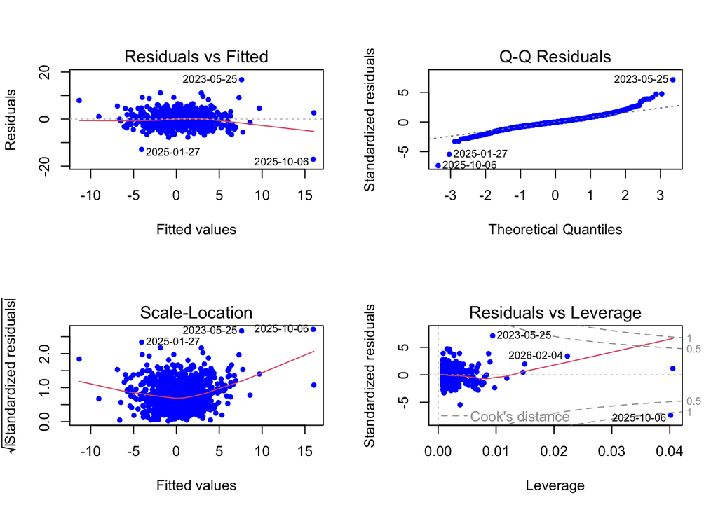

```r
par(mfrow = c(2, 2))
plot(reg_simple, pch = 20, col = "blue")
```

```r
bp_simple <- bptest(reg_simple)
cat("Breusch-Pagan p-value:", bp_simple$p.value, "\n")
```

```
## Breusch-Pagan p-value: 7.154455e-08
```

El Breusch-Pagan rechaza homocedasticidad (p = 0). La volatilidad de NVDA y AMD no es constante, hay periodos de alta volatilidad y periodos de calma. Esto no invalida las estimaciones de los betas pero sí afecta la confiabilidad de los errores estándar. Para un análisis más robusto se podrían usar errores estándar de Newey-West, pero dado que los t-stats son tan altos (t = 33.4 para AMD), la significancia no cambiaría.

## Regresión Lineal Múltiple

### Modelo completo

Ahora metemos las 10 acciones como variables independientes.

NVDA = alpha + B1 AAPL + B2 META + B3 AMD + B4 INTC + B5 PLTR + B6 LMT + B7 GD + B8 JPM + B9 JNJ + B10 XOM

```r
reg_multi <- lm(NVDA ~ AAPL + META + AMD + INTC + PLTR + LMT + GD + JPM + JNJ + XOM,
                data = retornos)
s_multi <- summary(reg_multi)
print(s_multi)
```

```
##
## Call:
## lm(formula = NVDA ~ AAPL + META + AMD + INTC + PLTR + LMT + GD +
##     JPM + JNJ + XOM, data = retornos)
##
## Residuals:
##      Min       1Q   Median       3Q      Max
## -13.5125  -1.1392  -0.0809   1.0258  17.7229
##
## Coefficients:
##             Estimate Std. Error t value Pr(>|t|)
## (Intercept)  0.15926    0.06085   2.617  0.00897 **
## AAPL         0.30978    0.04476   6.921 7.15e-12 ***
## META         0.14389    0.02707   5.316 1.25e-07 ***
## AMD          0.44034    0.02333  18.874  < 2e-16 ***
## INTC         0.03681    0.02301   1.600  0.10990
## PLTR         0.10760    0.01746   6.163 9.65e-10 ***
## LMT         -0.11873    0.05411  -2.194  0.02839 *
## GD           0.07143    0.06797   1.051  0.29354
## JPM          0.13781    0.04782   2.882  0.00402 **
## JNJ         -0.33203    0.06179  -5.374 9.20e-08 ***
## XOM         -0.07249    0.04044  -1.793  0.07328 .
## ---
## Signif. codes:  0 '***' 0.001 '**' 0.01 '*' 0.05 '.' 0.1 ' ' 1
##
## Residual standard error: 2.147 on 1244 degrees of freedom
## Multiple R-squared:  0.5686, Adjusted R-squared:  0.5651
## F-statistic:   164 on 10 and 1244 DF,  p-value: < 2.2e-16
```

```r
cat("R2:", round(s_multi$r.squared, 4), "\n")
```

```
## R2: 0.5686
```

```r
cat("R2 Ajustado:", round(s_multi$adj.r.squared, 4), "\n")
```

```
## R2 Ajustado: 0.5651
```

```r
cat("F-statistic:", round(s_multi$fstatistic[1], 2), "\n")
```

```
## F-statistic: 163.97
```

```r
cat("Observaciones:", nobs(reg_multi), "\n")
```

```
## Observaciones: 1255
```

*Interpretación:* El modelo múltiple sube el R2 a 0.569, lo que significa que el portafolio de 10 acciones explica el 57% de la variación diaria de NVDA. La ganancia de +9.7 puntos porcentuales sobre la regresión simple (0.472) puede parecer pequeña por agregar 9 variables, pero es estadísticamente significativa y consistente con lo que vimos en la Tarea 7, la mayor parte de la variación de NVDA se explica con 1 o 2 acciones del mismo sector, y el resto del portafolio aporta información marginal pero real.

```r
coefs <- s_multi$coefficients
sig <- coefs[coefs[, 4] < 0.05 & rownames(coefs) != "(Intercept)", ]
cat("Variables significativas:\n")
```

```
## Variables significativas:
```

```r
print(round(sig, 4))
```

```
##      Estimate Std. Error t value Pr(>|t|)
## AAPL   0.3098     0.0448  6.9213   0.0000
## META   0.1439     0.0271  5.3162   0.0000
## AMD    0.4403     0.0233 18.8740   0.0000
## PLTR   0.1076     0.0175  6.1625   0.0000
## LMT   -0.1187     0.0541 -2.1944   0.0284
## JPM    0.1378     0.0478  2.8820   0.0040
## JNJ   -0.3320     0.0618 -5.3738   0.0000
```

```r
nosig <- coefs[coefs[, 4] >= 0.05 & rownames(coefs) != "(Intercept)", ]
cat("\nVariables NO significativas:\n")
```

```
##
## Variables NO significativas:
```

```r
print(round(nosig, 4))
```

```
##      Estimate Std. Error t value Pr(>|t|)
## INTC   0.0368     0.0230  1.5998   0.1099
## GD     0.0714     0.0680  1.0508   0.2935
## XOM   -0.0725     0.0404 -1.7926   0.0733
```

*Interpretación:* De las 10 variables, 7 son significativas al 5%. AMD con un beta de 0.44 y t de 18.9 y AMD sigue siendo el predictor más fuerte. AAPL (beta = 0.31, t = 6.9) y META (beta = 0.14, t = 5.3) capturan el sentimiento tech general que AMD no absorbe completamente. PLTR es significativa (beta = 0.11, t = 6.2 confirmando que el mercado ve una conexión AI entre PLTR y NVDA. JNJ tiene el segundo beta más grande en valor absoluto (-0.33, t = -5.4), y su signo negativo refleja el efecto de rotación sectorial . LMT también es negativa (-0.12, t = -2.2), misma lógica pero con menor magnitud. JPM es positiva (0.14, t = 2.9) porque captura la salud del mercado en general,cuando el sistema financiero está bien hay más crédito y más inversión en tecnología. INTC, GD y XOM no son significativas. INTC (p = 0.11) pierde significancia en el modelo múltiple porque su información ya está contenida en AMD, ambas son semiconductoras . GD (p = 0.29) es redundante con LMT por pertenecer al mismo sector. XOM (p = 0.07) probablemente sería significativa con una muestra más grande o con un nivel de significancia del 10%.

### Multicolinealidad (VIF)

```r
vif_vals <- vif(reg_multi)
sort(vif_vals, decreasing = TRUE)
```

```
##       GD      AMD     AAPL      LMT     META      JPM     PLTR     INTC
## 1.987861 1.668226 1.634739 1.605171 1.499163 1.470795 1.411218 1.317380
##      XOM      JNJ
## 1.255291 1.146235
```

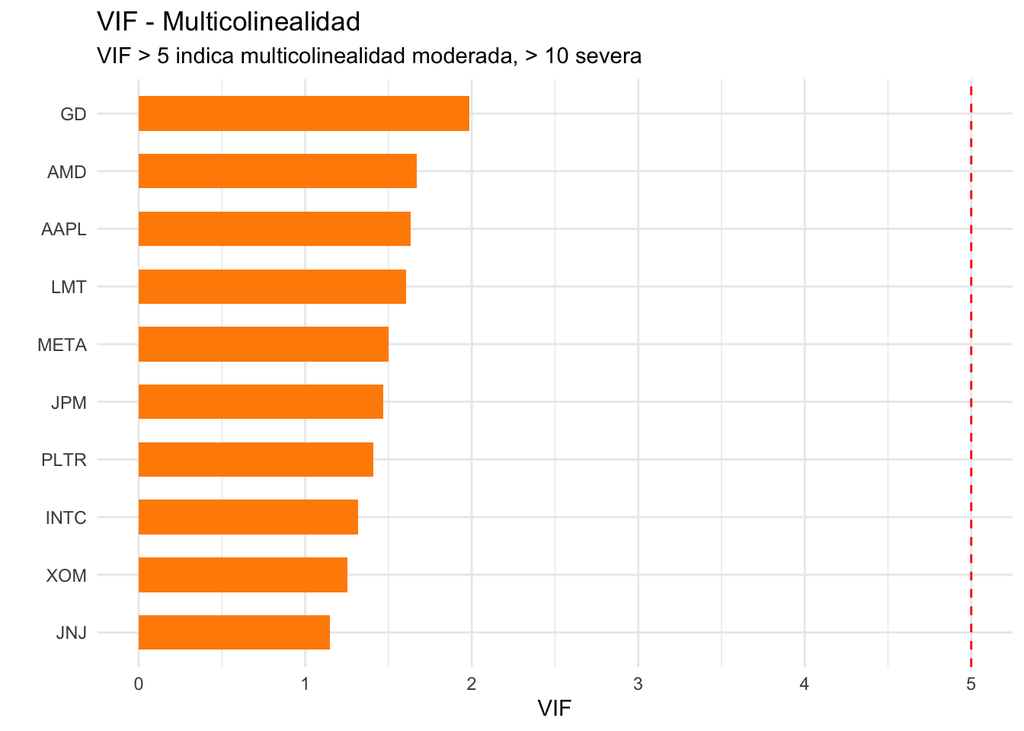

```r
vif_df <- data.frame(Variable = names(vif_vals), VIF = as.numeric(vif_vals))

ggplot(vif_df, aes(x = reorder(Variable, VIF), y = VIF,
                    fill = ifelse(VIF > 5, "alto", "ok"))) +
  geom_col(width = 0.6) +
  geom_hline(yintercept = 5, linetype = "dashed", color = "red") +
  scale_fill_manual(values = c("alto" = "red", "ok" = "darkorange"), guide = "none") +
  coord_flip() +
  labs(title = "VIF - Multicolinealidad",
       subtitle = "VIF > 5 indica multicolinealidad moderada, > 10 severa",
       x = "", y = "VIF") +
  theme_minimal()
```

*Interpretación:* Todos los VIF están entre 1.1 y 2.0, muy por debajo del 5. Esto es mejor de lo que esperaba considerando que tenemos 5 acciones tech en el modelo. La razón es que aunque AAPL, META, AMD, INTC y PLTR están correlacionadas entre sí (0.3-0.5), no al punto de generar multicolinealidad severa. Cada una captura un aspecto distinto del mercado tech, AMD el segmento de semis, META el de advertising/AI, PLTR el de software/gobierno, etc. El VIF más alto es GD (1.99) por su correlación de 0.59 con LMT, pero sigue siendo bajo. En resumen, no hay problemas de multicolinealidad y los coeficientes son confiables.

### Gráfica de coeficientes

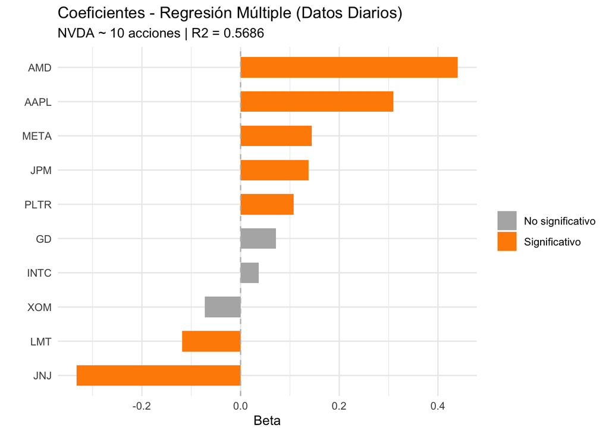

```r
coef_df <- data.frame(
  Variable = names(coef(reg_multi))[-1],
  Beta = coef(reg_multi)[-1],
  Sig = ifelse(s_multi$coefficients[-1, 4] < 0.05, "Significativo", "No significativo")
)

ggplot(coef_df, aes(x = reorder(Variable, Beta), y = Beta, fill = Sig)) +
  geom_col(width = 0.6) +
  geom_hline(yintercept = 0, linetype = "dashed", color = "gray") +
  scale_fill_manual(values = c("Significativo" = "darkorange", "No significativo" = "gray70")) +
  coord_flip() +
  labs(title = "Coeficientes - Regresión Múltiple (Datos Diarios)",
       subtitle = paste("NVDA ~ 10 acciones | R2 =", round(s_multi$r.squared, 4)),
       x = "", y = "Beta", fill = "") +
  theme_minimal()
```

### Diagnóstico

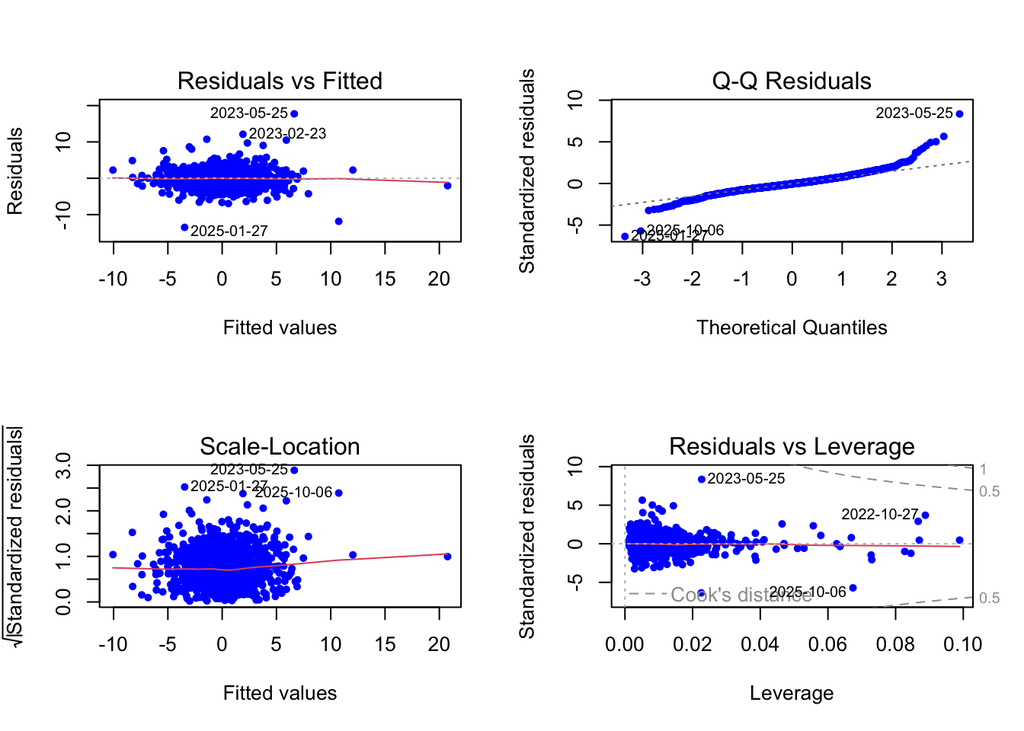

```r
par(mfrow = c(2, 2))
plot(reg_multi, pch = 20, col = "blue")
```

```r
bp_multi <- bptest(reg_multi)
cat("Breusch-Pagan p-value:", bp_multi$p.value, "\n\n")
```

```
## Breusch-Pagan p-value: 1.378551e-05
```

```r
dw_multi <- dwtest(reg_multi)
cat("Durbin-Watson:", round(dw_multi$statistic, 4), "p-value:", round(dw_multi$p.value, 4), "\n")
```

```
## Durbin-Watson: 2.1279 p-value: 0.9881
```

*Interpretación*: El Durbin-Watson de 2.13 (p = 0.99) confirma que no hay autocorrelación serial en los residuales, lo que es bueno. Esto significa que los errores de un día no predicen los errores del siguiente, el modelo no está dejando estructura temporal sin capturar. El Breusch-Pagan sí detecta heterocedasticidad (p = 0), que es consistente con lo que vimos en el modelo simple

### Comparación de modelos

```r
cat("Métrica              Simple        Múltiple\n")
```

```
## Métrica              Simple        Múltiple
```

```r
cat("-------------------------------------------\n")
cat(sprintf("R2                  %.4f         %.4f\n",
    summary(reg_simple)$r.squared, s_multi$r.squared))
```

```
## R2                  0.4716         0.5686
```

```r
cat(sprintf("R2 ajustado          %.4f         %.4f\n",
    summary(reg_simple)$adj.r.squared, s_multi$adj.r.squared))
```

```
## R2 ajustado          0.4712         0.5651
```

```r
cat(sprintf("AIC                  %.2f     %.2f\n",
    AIC(reg_simple), AIC(reg_multi)))
```

```
## AIC                  5729.16     5492.53
```

```r
cat(sprintf("BIC                  %.2f     %.2f\n",
    BIC(reg_simple), BIC(reg_multi)))
```

```
## BIC                  5744.57     5554.15
```

```r
cat(sprintf("Variables            1              10\n"))
```

```
## Variables            1              10
```

```r
anova(reg_simple, reg_multi)
```

```
## Analysis of Variance Table
##
## Model 1: NVDA ~ AMD
## Model 2: NVDA ~ AAPL + META + AMD + INTC + PLTR + LMT + GD + JPM + JNJ +
##     XOM
##   Res.Df    RSS Df Sum of Sq      F    Pr(>F)
## 1   1253 7025.5
## 2   1244 5735.4  9    1290.1 31.092 < 2.2e-16 ***
## ---
## Signif. codes:  0 '***' 0.001 '**' 0.01 '*' 0.05 '.' 0.1 ' ' 1
```

*Interpretación:* El test F del ANOVA rechaza la hipótesis de que las 9 variables adicionales no aportan (p < 2.2e-16). El AIC también favorece al modelo múltiple (5,493 vs 5,729), el AIC penaliza por número de variables, y aun así el múltiple sale mejor. Dicho esto la mayor parte del poder explicativo viene de AMD, de un R2 total de 0.569, AMD sola aporta 0.472 y las otras 9 variables juntas aportan los 0.097 restantes. Esto sugiere que para predecir NVDA en la práctica, basta con seguir a AMD y tener una idea general de el sentimiento del mercado

# Parte 2: Regresiones con datos intradiarios (5 Minutos)

Para verificar que las relaciones que encontramos con datos diarios no son un tema de la frecuencia de muestreo, repetimos todo el análisis usando precios de cierre a intervalos de 5 minutos de Refinitiv. La lógica es que si AMD sigue siendo el mejor predictor de NVDA en datos de 5 minutos, entonces las relaciones son estructurales y reflejan algo real del mercado

## Carga de datos intradiarios

```r
intra_raw <- read_excel("INTRADAY5MIN.xlsx", sheet = "Table Data", skip = 1)
colnames(intra_raw) <- c("DateTime", "NVDA", "AAPL", "META", "AMD", "INTC",
                          "PLTR", "LMT", "GD", "JPM", "JNJ", "XOM")

intra_raw$DateTime <- as.POSIXct(intra_raw$DateTime)
intra_raw <- intra_raw[order(intra_raw$DateTime), ]
intra_raw <- na.omit(intra_raw)

cat("Datos Intradiarios (5 min):", nrow(intra_raw), "observaciones\n")
```

```
## Datos Intradiarios (5 min): 394 observaciones
```

```r
cat("Periodo:", as.character(min(intra_raw$DateTime)), "a", as.character(max(intra_raw$DateTime)), "\n")
```

```
## Periodo: 2026-03-11 a 2026-03-17
```

```r
cat("Días de trading:", length(unique(as.Date(intra_raw$DateTime))), "\n")
```

```
## Días de trading: 5
```

```r
cat("Observaciones por día:", nrow(intra_raw) / length(unique(as.Date(intra_raw$DateTime))), "\n")
```

```
## Observaciones por día: 78.8
```

## Retornos de 5 minutos

```r
ret_intra <- data.frame( DateTime = intra_raw$DateTime[-1],sapply(intra_raw[, -1], function(x) diff(x) / head(x, -1) * 100))
colnames(ret_intra) <- c("DateTime", "NVDA", "AAPL", "META", "AMD", "INTC", "PLTR", "LMT", "GD", "JPM", "JNJ", "XOM")

ret_intra$is_overnight <- c(FALSE, diff(as.Date(ret_intra$DateTime)) > 0)
cat("Retornos overnight eliminados:", sum(ret_intra$is_overnight), "\n")
```

```
## Retornos overnight eliminados: 4
```

```r
ret_clean <- ret_intra[!ret_intra$is_overnight, ]

cat("Retornos intradiarios limpios:", nrow(ret_clean), "observaciones\n")
```

```
## Retornos intradiarios limpios: 389 observaciones
```

## Estadísticas intradiarias

```r
tickers <- c("NVDA", "AAPL", "META", "AMD", "INTC", "PLTR", "LMT", "GD", "JPM", "JNJ", "XOM")

cat("Volatilidad intradiaria (desv. est. retornos 5-min %):\n")
```

```
## Volatilidad intradiaria (desv. est. retornos 5-min %):
```

```r
vol_intra <- sort(sapply(ret_clean[, tickers], sd), decreasing = TRUE)
print(round(vol_intra, 4))
```

```
##   INTC   PLTR    AMD   NVDA    LMT     GD    JPM   META    XOM    JNJ   AAPL
## 0.2911 0.2493 0.2056 0.2014 0.1747 0.1498 0.1445 0.1419 0.1264 0.1212 0.1083
```

```r
cat("\nVolatilidad diaria (referencia, desv. est. retornos diarios %):\n")
```

```
##
## Volatilidad diaria (referencia, desv. est. retornos diarios %):
```

```r
vol_daily <- sort(sapply(retornos[, tickers], sd), decreasing = TRUE)
print(round(vol_daily, 4))
```

```
##   PLTR    AMD   NVDA   INTC   META   AAPL    XOM    JPM    LMT     GD    JNJ
## 4.1255 3.3568 3.2561 3.0250 2.7429 1.7321 1.6799 1.5378 1.4199 1.2577 1.0507
```

*Interpretación:* El ranking de volatilidad cambió entre frecuencias, en datos diarios el top 3 es PLTR > AMD > NVDA, pero en 5 minutos es INTC > PLTR > AMD. Que INTC salte al primer lugar en volatilidad tiene sentido porque es una acción en declive donde la actividad especulativa genera más ruido en ventanas cortas. Las magnitudes son mucho menores (movimientos de 5 minutos vs un día completo), pero el hecho de que PLTR, AMD y NVDA se mantengan en el top 4 en ambas frecuencias confirma que la volatilidad de estas acciones es una propiedad fundamental. JNJ sigue siendo la más estable en datos diarios (1.05%) y la segunda más estable en intradiario (0.12%), lo que refuerza su rol como ancla defensiva del portafolio

## Correlaciones intradiarias vs diarias

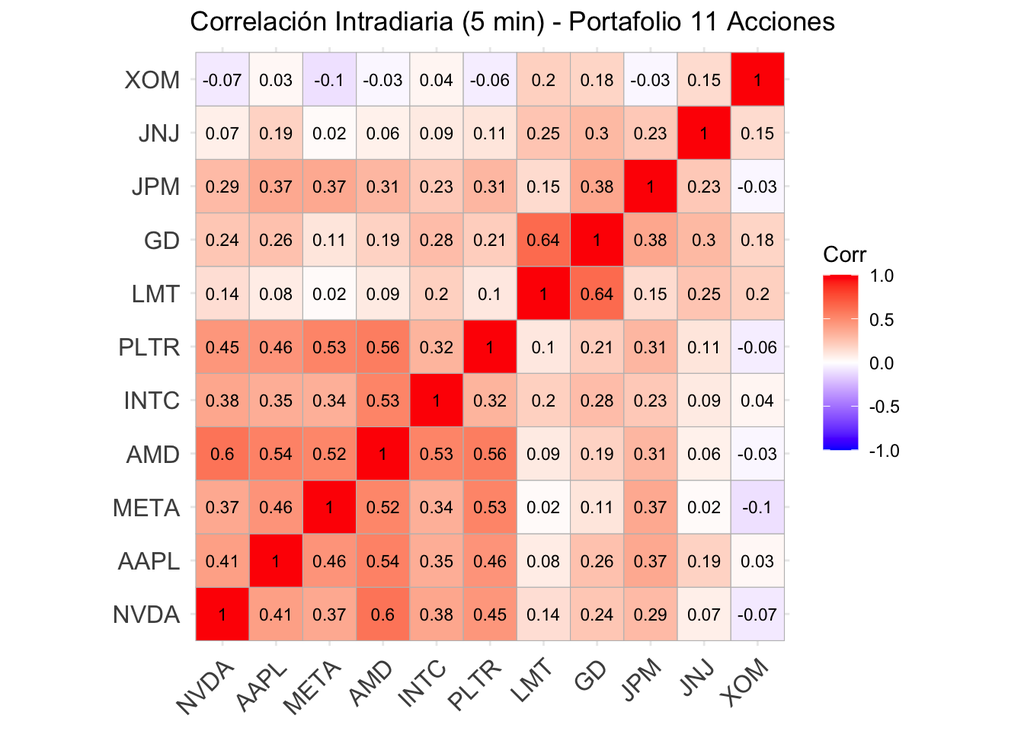

```r
cor_intra <- cor(ret_clean[, tickers])

ggcorrplot(cor_intra, lab = TRUE, lab_size = 3,
           title = "Correlación Intradiaria (5 min) - Portafolio 11 Acciones")
```

```r
cor_compare <- data.frame(
  Ticker = tickers[tickers != "NVDA"],
  Diaria = round(cor_mat["NVDA", tickers[tickers != "NVDA"]], 3),
  Intradiaria = round(cor_intra["NVDA", tickers[tickers != "NVDA"]], 3)
)
cor_compare$Diferencia <- cor_compare$Intradiaria - cor_compare$Diaria

cat("Correlaciones con NVDA — Diaria vs Intradiaria:\n")
```

```
## Correlaciones con NVDA — Diaria vs Intradiaria:
```

```r
print(cor_compare[order(-cor_compare$Diaria), ])
```

```
##      Ticker Diaria Intradiaria Diferencia
## AMD     AMD  0.687       0.598     -0.089
## AAPL   AAPL  0.508       0.413     -0.095
## META   META  0.493       0.372     -0.121
## PLTR   PLTR  0.488       0.454     -0.034
## INTC   INTC  0.370       0.381      0.011
## JPM     JPM  0.325       0.285     -0.040
## GD       GD  0.160       0.245      0.085
## XOM     XOM  0.088      -0.067     -0.155
## LMT     LMT -0.026       0.143      0.169
## JNJ     JNJ -0.100       0.070      0.170
```

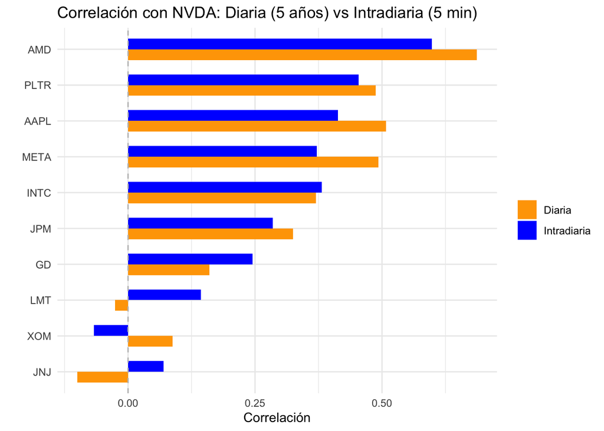

```r
cor_long <- pivot_longer(cor_compare, cols = c("Diaria", "Intradiaria"),
                          names_to = "Frecuencia", values_to = "Correlacion")

ggplot(cor_long, aes(x = reorder(Ticker, Correlacion), y = Correlacion, fill = Frecuencia)) +
  geom_col(position = "dodge", width = 0.6) +
  geom_hline(yintercept = 0, linetype = "dashed", color = "gray") +
  scale_fill_manual(values = c("Diaria" = "orange", "Intradiaria" = "blue")) +
  coord_flip() +
  labs(title = "Correlación con NVDA: Diaria (5 años) vs Intradiaria (5 min)",
       x = "", y = "Correlación", fill = "") +
  theme_minimal()
```

Los cambios más grandes están en las acciones defensivas. JNJ pasa de correlación negativa (-0.10) a ligeramente positiva (+0.07), y LMT pasa de -0.03 a +0.14. Esto significa que el efecto de rotación sectorial que vimos en datos diarios (donde los inversionistas salen de tech y entran a defensivos, generando correlaciones negativas) no opera en ventanas de 5 minutos. Es un fenómeno que tarda horas o días en manifestarse no minutos. XOM pasa de correlación positiva (0.09) a negativa (-0.07), sugiriendo que en el muy corto plazo los movimientos de energía y semiconductores son ligeramente contrario

## Regresión simple Intradiaria: NVDA ~ AMD

```r
reg_simple_intra <- lm(NVDA ~ AMD, data = ret_clean)
s_simple_intra <- summary(reg_simple_intra)
print(s_simple_intra)
```

```
##
## Call:
## lm(formula = NVDA ~ AMD, data = ret_clean)
##
## Residuals:
##      Min       1Q   Median       3Q      Max
## -1.71142 -0.06695 -0.00686  0.07349  0.83691
##
## Coefficients:
##              Estimate Std. Error t value Pr(>|t|)
## (Intercept) 0.0006129  0.0082299   0.074    0.941
## AMD         0.5857646  0.0399171  14.675   <2e-16 ***
## ---
## Signif. codes:  0 '***' 0.001 '**' 0.01 '*' 0.05 '.' 0.1 ' ' 1
##
## Residual standard error: 0.1617 on 387 degrees of freedom
## Multiple R-squared:  0.3575, Adjusted R-squared:  0.3558
## F-statistic: 215.3 on 1 and 387 DF,  p-value: < 2.2e-16
```

```r
cat("\n--- Comparación Regresión Simple ---\n")
```

```
##
## --- Comparación Regresión Simple ---
```

```r
cat(sprintf("%-25s %-15s %-15s\n", "Métrica", "Diario (5Y)", "Intradiario (5min)"))
```

```
## Métrica                  Diario (5Y)     Intradiario (5min)
```

```r
cat("-----------------------------------------------------\n")
cat(sprintf("%-25s %-15.4f %-15.4f\n", "R2",
    summary(reg_simple)$r.squared, s_simple_intra$r.squared))
```

```
## R2                        0.4716          0.3575
```

```r
cat(sprintf("%-25s %-15.4f %-15.4f\n", "Beta (AMD)",
    coef(reg_simple)[2], coef(reg_simple_intra)[2]))
```

```
## Beta (AMD)                0.6661          0.5858
```

```r
cat(sprintf("%-25s %-15.4f %-15.4f\n", "Alpha (intercepto)",
    coef(reg_simple)[1], coef(reg_simple_intra)[1]))
```

```
## Alpha (intercepto)        0.1789          0.0006
```

```r
cat(sprintf("%-25s %-15.0f %-15.0f\n", "Observaciones",
    nobs(reg_simple), nobs(reg_simple_intra)))
```

```
## Observaciones             1255            389
```

*Interpretación:* La comparación de la regresión simple entre timeframes dice mucho… El R2 baja de 0.47 a 0.36, AMD sigue explicando una parte importante de NVDA en 5 minutos, pero menos que en datos diarios. El beta baja de 0.67 a 0.59, lo que indica que la sensibilidad de NVDA a AMD es menor en el intradía, porque en ventanas tan cortas hay movimientos idiosincráticos (órdenes grandes, rebalanceos de ETFs) que afectan a una sin mover a la otra.

El hallazgo más interesante es el intercepto es que en datos diarios era 0.179 y significativo (p = 0.008), sugiriendo que un alpha positivo de NVDA. En datos de 5 minutos es casi cero (0.0006, p = 0.94). El alpha de NVDA se genera por su posición en AI y esa ventaja se acumula gradualmente . En ventanas de 5 minutos no hay alpha porque no hay nueva información que absorber

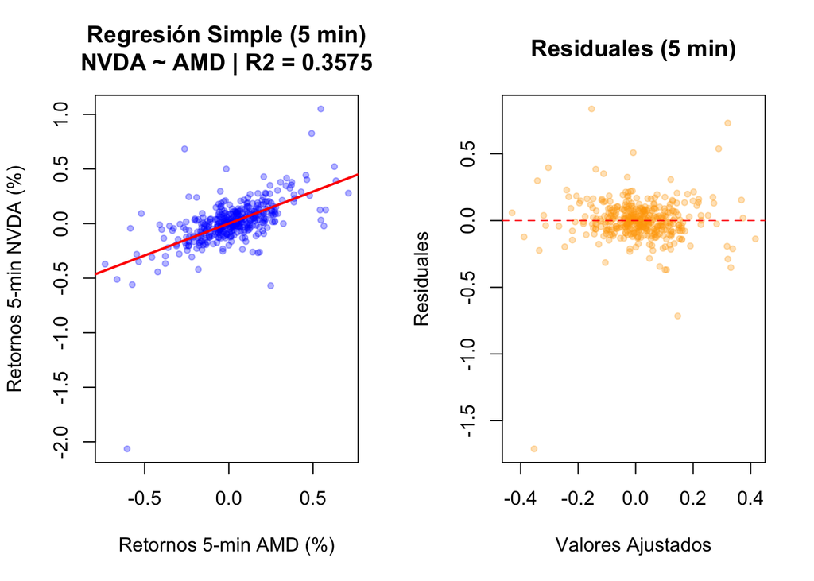

```r
par(mfrow = c(1, 2))

plot(ret_clean$AMD, ret_clean$NVDA, pch = 20, col = adjustcolor("blue", 0.3),
     xlab = "Retornos 5-min AMD (%)", ylab = "Retornos 5-min NVDA (%)",
     main = paste("Regresión Simple (5 min)\nNVDA ~ AMD | R2 =",
                  round(s_simple_intra$r.squared, 4)))
abline(reg_simple_intra, col = "red", lwd = 2)

plot(fitted(reg_simple_intra), resid(reg_simple_intra),
     pch = 20, col = adjustcolor("orange", 0.3),
     xlab = "Valores Ajustados", ylab = "Residuales",
     main = "Residuales (5 min)")
abline(h = 0, col = "red", lty = 2)
```

## Regresión Múltiple intradiaria: NVDA ~ 10 acciones

```r
reg_multi_intra <- lm(NVDA ~ AAPL + META + AMD + INTC + PLTR + LMT + GD + JPM + JNJ + XOM,
                       data = ret_clean)
s_multi_intra <- summary(reg_multi_intra)
print(s_multi_intra)
```

```
##
## Call:
## lm(formula = NVDA ~ AAPL + META + AMD + INTC + PLTR + LMT + GD +
##     JPM + JNJ + XOM, data = ret_clean)
##
## Residuals:
##      Min       1Q   Median       3Q      Max
## -1.67746 -0.06373 -0.00332  0.05877  0.79322
##
## Coefficients:
##               Estimate Std. Error t value Pr(>|t|)
## (Intercept) -0.0006781  0.0081796  -0.083   0.9340
## AAPL         0.1367647  0.0954333   1.433   0.1527
## META        -0.0063831  0.0740823  -0.086   0.9314
## AMD          0.4190691  0.0565297   7.413 8.16e-13 ***
## INTC         0.0357479  0.0335213   1.066   0.2869
## PLTR         0.1060295  0.0421399   2.516   0.0123 *
## LMT          0.0369429  0.0613554   0.602   0.5475
## GD           0.1124188  0.0776786   1.447   0.1487
## JPM          0.0585795  0.0663999   0.882   0.3782
## JNJ         -0.0349854  0.0715092  -0.489   0.6250
## XOM         -0.1101879  0.0657943  -1.675   0.0948 .
## ---
## Signif. codes:  0 '***' 0.001 '**' 0.01 '*' 0.05 '.' 0.1 ' ' 1
##
## Residual standard error: 0.1575 on 378 degrees of freedom
## Multiple R-squared:  0.4039, Adjusted R-squared:  0.3882
## F-statistic: 25.61 on 10 and 378 DF,  p-value: < 2.2e-16
```

```r
cat("\n--- Comparación Regresión Múltiple ---\n")
```

```
##
## --- Comparación Regresión Múltiple ---
```

```r
cat(sprintf("%-25s %-15s %-15s\n", "Métrica", "Diario (5Y)", "Intradiario (5min)"))
```

```
## Métrica                  Diario (5Y)     Intradiario (5min)
```

```r
cat("-----------------------------------------------------\n")
cat(sprintf("%-25s %-15.4f %-15.4f\n", "R2", s_multi$r.squared, s_multi_intra$r.squared))
```

```
## R2                        0.5686          0.4039
```

```r
cat(sprintf("%-25s %-15.4f %-15.4f\n", "R2 Ajustado", s_multi$adj.r.squared, s_multi_intra$adj.r.squared))
```

```
## R2 Ajustado               0.5651          0.3882
```

```r
cat(sprintf("%-25s %-15.0f %-15.0f\n", "Observaciones", nobs(reg_multi), nobs(reg_multi_intra)))
```

```
## Observaciones             1255            389
```

```r
cat("\nComparación de betas:\n")
```

```
##
## Comparación de betas:
```

```r
betas_daily <- coef(reg_multi)[-1]
betas_intra <- coef(reg_multi_intra)[-1]
sig_daily <- s_multi$coefficients[-1, 4]
sig_intra <- s_multi_intra$coefficients[-1, 4]

comp_betas <- data.frame(
  Ticker = names(betas_daily),
  Beta_Diario = round(betas_daily, 4),
  Beta_5min = round(betas_intra, 4),
  Sig_Diario = ifelse(sig_daily < 0.05, "***", ifelse(sig_daily < 0.1, ".", "")),
  Sig_5min = ifelse(sig_intra < 0.05, "***", ifelse(sig_intra < 0.1, ".", ""))
)
rownames(comp_betas) <- NULL
print(comp_betas)
```

```
##    Ticker Beta_Diario Beta_5min Sig_Diario Sig_5min
## 1    AAPL      0.3098    0.1368        ***
## 2    META      0.1439   -0.0064        ***
## 3     AMD      0.4403    0.4191        ***      ***
## 4    INTC      0.0368    0.0357
## 5    PLTR      0.1076    0.1060        ***      ***
## 6     LMT     -0.1187    0.0369        ***
## 7      GD      0.0714    0.1124
## 8     JPM      0.1378    0.0586        ***
## 9     JNJ     -0.3320   -0.0350        ***
## 10    XOM     -0.0725   -0.1102          .        .
```

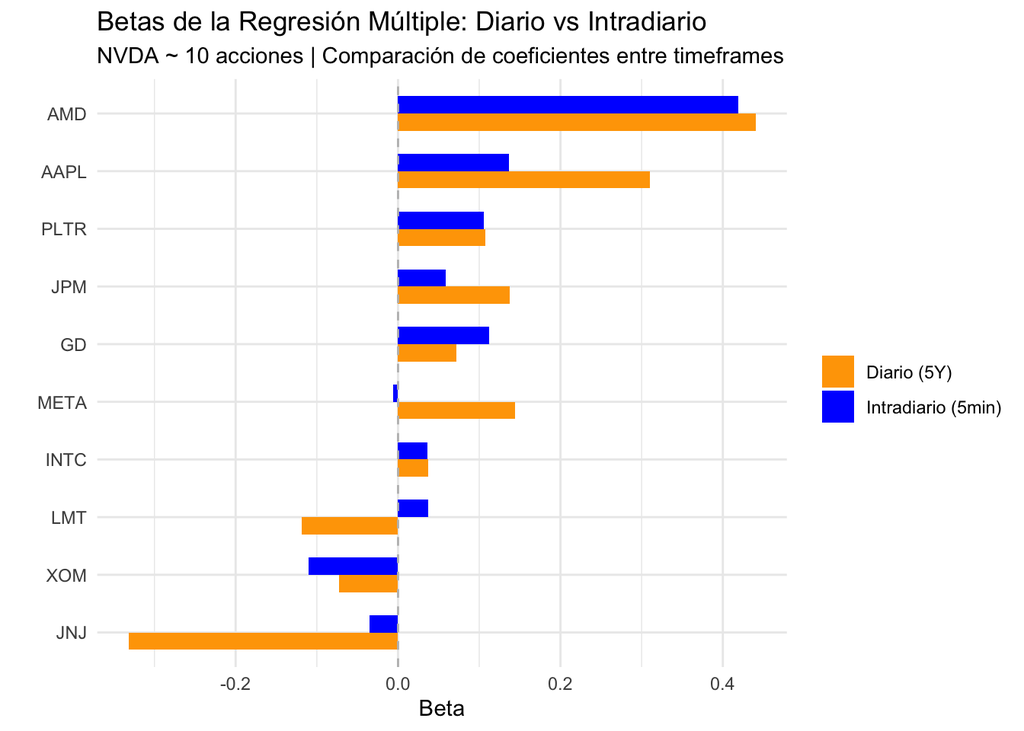

```r
comp_long <- data.frame(
  Ticker = rep(names(betas_daily), 2),
  Beta = c(betas_daily, betas_intra),
  Frecuencia = rep(c("Diario (5Y)", "Intradiario (5min)"), each = length(betas_daily))
)

ggplot(comp_long, aes(x = reorder(Ticker, Beta), y = Beta, fill = Frecuencia)) +
  geom_col(position = "dodge", width = 0.6) +
  geom_hline(yintercept = 0, linetype = "dashed", color = "gray") +
  scale_fill_manual(values = c("Diario (5Y)" = "orange", "Intradiario (5min)" = "blue")) +
  coord_flip() +
  labs(title = "Betas de la Regresión Múltiple: Diario vs Intradiario",
       subtitle = "NVDA ~ 10 acciones | Comparación de coeficientes entre timeframes",
       x = "", y = "Beta", fill = "") +
  theme_minimal()
```

*Interpretación:* La comparación de betas revela wque en datos de 5 minutos, solo AMD y PLTR mantienen su significancia estadística. De las 7 variables significativas en el modelo diario5 pierden significancia en el intradía (AAPL, META, JPM, LMT, JNJ).

Esto no significa que esas relaciones no existan pero si que operan en horizontes más largos. AMD (beta = 0.42, p = 0) y PLTR (beta = 0.11, p = 0.01) capturan relaciones que funcionan minuto a minuto, ambas reaccionan casi simultáneamente con NVDA ante flujos de mercado y noticias del sector AI. AAPL (beta = 0.14, p = 0.15) y META (beta = -0.006, p = 0.93) capturan sentimiento tech general que se manifiesta a lo largo del día, no en bloques de 5 minutos. META incluso cambia de signo , lo que sugiere que su movimiento con NVDA es un fenómeno diario.

El caso más notable es JNJ, su beta pasa de -0.33 (altamente significativo en datos diarios) a -0.035 (completamente no significativo, p = 0.63). El efecto de rotación sectorial tarda horas o días en desarrollarse a medida que los portfolio managers ajustan sus posiciones. En ventanas de 5 minutos JNJ simplemente no tiene relación con NVDA. Esto es consistente con lo que vimos en las correlaciones, JNJ pasó de -0.10 a +0.07 entre frecuencias.

LMT también pierde su beta negativo (-0.12 a +0.04) confirmando que el efecto de diversificación de defensa vs tech es un fenómeno de mediano plazo

La gráfica de barras lado a lado lo muestra visualmente, las barras de AMD y PLTR están parejas entre frecuencias mientras que las de JNJ, META y LMT difieren notablemente

## Diagnósticos Intradiarios

### Multicolinealidad (VIF)

```r
vif_intra <- vif(reg_multi_intra)

cat("VIF Intradiario:\n")
```

```
## VIF Intradiario:
```

```r
print(round(sort(vif_intra, decreasing = TRUE), 2))
```

```
##   GD  AMD  LMT META PLTR AAPL INTC  JPM  JNJ  XOM
## 2.12 2.11 1.80 1.73 1.72 1.67 1.49 1.44 1.17 1.08
```

```r
cat("\nComparación VIF (Diario vs Intradiario):\n")
```

```
##
## Comparación VIF (Diario vs Intradiario):
```

```r
vif_comp <- data.frame(  Variable = names(vif_vals),  VIF_Diario = round(as.numeric(vif_vals), 2),  VIF_5min = round(as.numeric(vif_intra[names(vif_vals)]), 2))
print(vif_comp[order(-vif_comp$VIF_5min), ])
```

```
##    Variable VIF_Diario VIF_5min
## 7        GD       1.99     2.12
## 3       AMD       1.67     2.11
## 6       LMT       1.61     1.80
## 2      META       1.50     1.73
## 5      PLTR       1.41     1.72
## 1      AAPL       1.63     1.67
## 4      INTC       1.32     1.49
## 8       JPM       1.47     1.44
## 9       JNJ       1.15     1.17
## 10      XOM       1.26     1.08
```

### Heterocedasticidad y Autocorrelación

```r
bp_intra <- bptest(reg_multi_intra)
cat("Breusch-Pagan (5 min): stat =", round(bp_intra$statistic, 4), "| p-value =", format(bp_intra$p.value, digits = 4), "\n\n")
```

```
## Breusch-Pagan (5 min): stat = 15.6348 | p-value = 0.1106
```

```r
dw_intra <- dwtest(reg_multi_intra)
cat("Durbin-Watson (5 min): DW =", round(dw_intra$statistic, 4),   "| p-value =", round(dw_intra$p.value, 4), "\n\n")
```

```
## Durbin-Watson (5 min): DW = 1.9445 | p-value = 0.2999
```

*Interpretación:* Los diagnósticos del modelo intradiario salieron bien porque el BP no detecta heterocedasticidad y el DW no detecta autocorrelación. Esto es raro en datos de 5 minutos yo esperaba encontrar autocorrelación por efectos de microestructura

Los VIF se mantienen por debajo de 2.2 en ambos tiempos confirmando que no hay multicolinealidad en ninguno de los dos modelos. AMD sube ligeramente (de 1.67 a 2.11), lo cual refleja que en el intradía su correlación con otras semis es un poco más fuert

### Corrección Newey-West

```r
cat("Regresión Múltiple Intradiaria con Errores Newey-West:\n")
```

```
## Regresión Múltiple Intradiaria con Errores Newey-West:
```

```r
cat("(Robustos a heterocedasticidad y autocorrelación)\n\n")
```

```
## (Robustos a heterocedasticidad y autocorrelación)
```

```r
nw_vcov <- vcovHAC(reg_multi_intra)
nw_test <- coeftest(reg_multi_intra, vcov = nw_vcov)
print(nw_test)
```

```
##
## t test of coefficients:
##
##                Estimate  Std. Error t value  Pr(>|t|)
## (Intercept) -0.00067812  0.00697369 -0.0972  0.922587
## AAPL         0.13676471  0.08960819  1.5263  0.127783
## META        -0.00638307  0.09335705 -0.0684  0.945525
## AMD          0.41906910  0.09556536  4.3852 1.505e-05 ***
## INTC         0.03574785  0.02469630  1.4475  0.148586
## PLTR         0.10602949  0.03798371  2.7914  0.005514 **
## LMT          0.03694293  0.04764105  0.7754  0.438563
## GD           0.11241881  0.05963604  1.8851  0.060186 .
## JPM          0.05857951  0.06399438  0.9154  0.360573
## JNJ         -0.03498545  0.07318136 -0.4781  0.632880
## XOM         -0.11018790  0.09864724 -1.1170  0.264708
## ---
## Signif. codes:  0 '***' 0.001 '**' 0.01 '*' 0.05 '.' 0.1 ' ' 1
```

```r
cat("\n--- Comparación de significancia: OLS estándar vs Newey-West ---\n")
```

```
##
## --- Comparación de significancia: OLS estándar vs Newey-West ---
```

```r
for (v in names(betas_intra)) {
  p_ols <- s_multi_intra$coefficients[v, 4]
  p_nw <- nw_test[v, 4]
  sig_ols <- ifelse(p_ols < 0.05, "Sig", "No sig")
  sig_nw <- ifelse(p_nw < 0.05, "Sig", "No sig")
  changed <- ifelse(sig_ols != sig_nw, "  <-- CAMBIO", "")
  cat(sprintf("  %-6s  OLS: %-6s (p=%.4f)  NW: %-6s (p=%.4f)%s\n",
              v, sig_ols, p_ols, sig_nw, p_nw, changed))
}
```

```
##   AAPL    OLS: No sig (p=0.1527)  NW: No sig (p=0.1278)
##   META    OLS: No sig (p=0.9314)  NW: No sig (p=0.9455)
##   AMD     OLS: Sig    (p=0.0000)  NW: Sig    (p=0.0000)
##   INTC    OLS: No sig (p=0.2869)  NW: No sig (p=0.1486)
##   PLTR    OLS: Sig    (p=0.0123)  NW: Sig    (p=0.0055)
##   LMT     OLS: No sig (p=0.5475)  NW: No sig (p=0.4386)
##   GD      OLS: No sig (p=0.1487)  NW: No sig (p=0.0602)
##   JPM     OLS: No sig (p=0.3782)  NW: No sig (p=0.3606)
##   JNJ     OLS: No sig (p=0.6250)  NW: No sig (p=0.6329)
##   XOM     OLS: No sig (p=0.0948)  NW: No sig (p=0.2647)
```

*Interpretación:* La corrección Newey-West no cambia ninguna conclusión, AMD y PLTR siguen siendo las únicas significativas, y las demás siguen sin serlo. Esto es bueno porque significa que los errores estándar del OLS no estaban inflados y los resultados son confiables tal cual. El hecho de que el modelo intradiario pase los diagnósticos sin problemas y la corrección robusta no altere nada le da credibilidad a la conclusión de que AMD y PLTR son las únicas acciones que realmente se mueve con con NVDA en tiempo real.

### Gráficos de diagnóstico

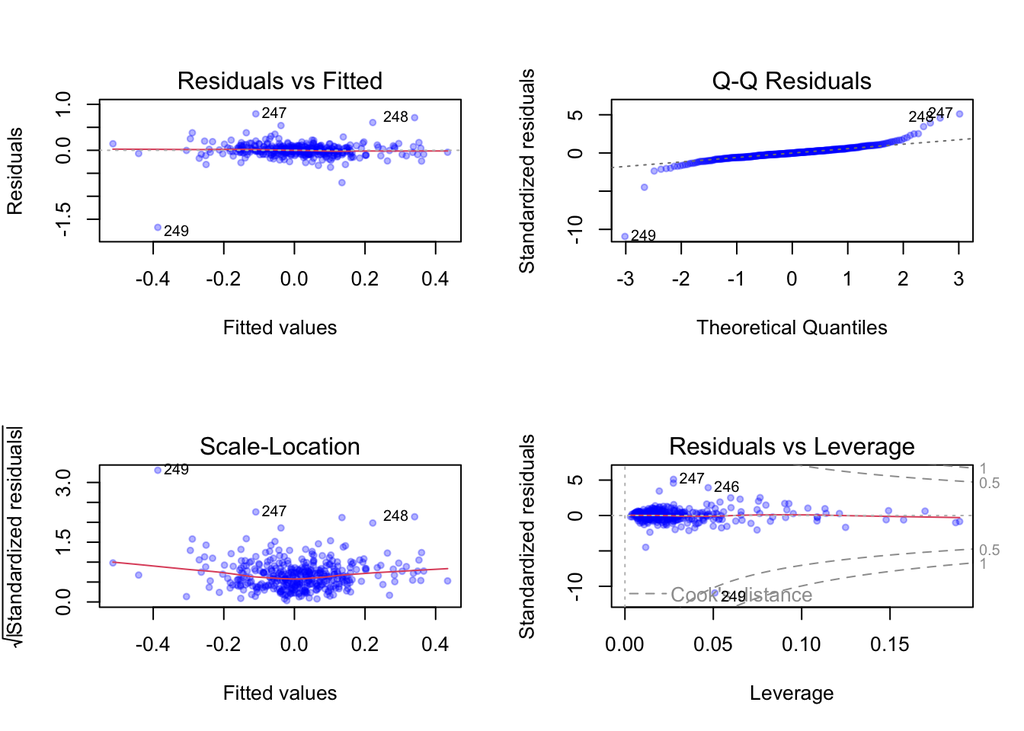

```r
par(mfrow = c(2, 2))
plot(reg_multi_intra, pch = 20, col = adjustcolor("blue", 0.3))
```

## Estabilidad día por día

```r
dias <- unique(as.Date(ret_clean$DateTime))
estab <- data.frame()

for (d in dias) {
  sub <- ret_clean[as.Date(ret_clean$DateTime) == d, ]
  if (nrow(sub) < 10) next
  m <- lm(NVDA ~ AMD, data = sub)
  s <- summary(m)
  estab <- rbind(estab, data.frame(
    Dia = as.Date(d),
    R2 = round(s$r.squared, 4),
    Beta = round(coef(m)[2], 4),
    Alpha = round(coef(m)[1], 4),
    Obs = nrow(sub),
    P_value = round(s$coefficients[2, 4], 4)
  ))
}

cat("Beta AMD por día individual:\n")
```

```
## Beta AMD por día individual:
```

```r
print(estab)
```

```
##             Dia     R2   Beta   Alpha Obs P_value
## AMD  2026-03-11 0.6104 0.5468 -0.0126  78       0
## AMD1 2026-03-12 0.5337 0.5240 -0.0088  78       0
## AMD2 2026-03-13 0.5648 0.6777  0.0132  78       0
## AMD3 2026-03-16 0.2348 0.7477  0.0030  78       0
## AMD4 2026-03-17 0.3033 0.4343  0.0076  77       0
```

```r
cat("\nBeta AMD promedio intradía:", round(mean(estab$Beta), 4), "\n")
```

```
##
## Beta AMD promedio intradía: 0.5861
```

```r
cat("Beta AMD modelo diario (5 años):", round(coef(reg_simple)[2], 4), "\n")
```

```
## Beta AMD modelo diario (5 años): 0.6661
```

```r
cat("Desv. est. del beta entre días:", round(sd(estab$Beta), 4), "\n")
```

```
## Desv. est. del beta entre días: 0.1254
```

*Interpretación:* El beta de AMD con NVDA varía entre 0.43 y 0.75 a lo largo de los 5 días, con un promedio de 0.586 y desviación estándar de 0.125. El promedio intradía (0.586) es cercano al beta diario de 5 años (0.666), lo que confirma que la relación es estable en distintas escalas de tiempo. La variación entre días (std = 0.125) es moderada, el 16 de marzo tuvo el beta más alto (0.75) y el 17 de marzo el más bajo (0.43), lo que sugiere que hubo algún evento o flujo ese día que movio temporalmente a las dos acciones. Lo importante es que el R2 es positivo y significativo (p = 0) los 5 días, confirmando que la relación NVDA-AMD no depende de un día en particular.

# Conclusión General

El análisis de regresión en dos timeframes, diario (5 años, 1,255 observaciones) e intradiario (5 minutos, 389 observaciones) revela que las relaciones del portafolio tienen dos capas… una de corto plazo que opera minuto a minuto, y otra de mediano plazo que se manifiesta a lo largo de días y semanas.

## Lo que se mantiene entre timeframes

AMD es el predictor más robusto de NVDA, sin importar la frecuencia. En datos diarios explica el 47% de la variación, en datos de 5 minutos el 36%. El beta es estable (0.67 diario, 0.59 intradía) y significativo en los 5 días analizados individualmente. Esto confirma que la conexión NVDA-AMD es estructural, ambas compiten en el mismo mercado de y los flujos del mercado las mueven juntas en tiempo real PLTR también sobrevive ambos timeframes. Es la única otra acción que mantiene significancia estadística en datos de 5 minutos (beta = 0.11, p = 0.01). Esto valida que el mercado trata a PLTR como AI junto con NVDA, y que esa relación opera en el intradía

## Lo que cambia entre timeframes

El efecto de rotación sectorial es un fenómeno de mediano plazo. JNJ pasa de ser el mejor cobertura de NVDA en datos diarios con un beta = -0.33, altamente significativo) a no tener relación en datos de 5 minutos (beta = -0.035, p = 0.63). Lo mismo pasa con LMT. La rotación de capital entre sectores la ejecutan portfolio managers que toman decisiones a lo largo del día o la semana, no en 5 minutos. Para mi portafolio esto significa que JNJ y LMT sí protegen contra caídas sostenidas de NVDA, pero no contra movimientos intradía

AAPL, META y JPM también pierden significancia en el intradía. Estas acciones capturan sentimiento general del mercado (tech, financiero) que se consolida a lo largo del día, no en el muy corto plazo. META incluso cambia de signo en su beta, confirmando que su comovimiento con NVDA es un efecto diario

El alpha de NVDA desaparece en 5 minutos. El intercepto significativo en datos diarios (0.179, p = 0.008) se vuelve cero en el intradía (0.0006, p = 0.94). La generación de alpha de NVDA se acumula gradualmente y no es observable en ventanas tan cortas.

## Conexión con el resto del proyecto

Las regresiones capturan las elaciones entre las acciones, cómo se mueven juntas en el presente. El Colab Notebook complementa esto con tres dimensiones adicionales:

El panel data con reportes trimestrales de Refinitiv muestra que el margen neto es el fundamental que más importa para explicar retornos en horizontes de trimestres. NVDA lidera con margen promedio de 42.71% y retorno trimestral de 17.49%. Mientras las regresiones dicen qué acciones se mueven juntas, el panel dice qué fundamentales hacen que una acción genere mejores retornos que otra.

Las series de tiempo con ARIMA confirman que las 11 acciones son no estacionarias y la mayoría sigue caminatas aleatorias. Esto no contradice las regresiones, las acciones se mueven juntas en el present pero su trayectoria futura individual es impredecible. El análisis de cointegración del Colab también mostró que NVDA-AMD no están cointegradas (p = 0.54), lo que explica por qué el beta intradía varía entre días, hay comovimiento de corto plazo pero no un equilibrio de largo plazo.

El GARCH reveló que NVDA tiene la mayor persistencia de volatilidad del portafolio. Combinado con los resultados de las regresiones, esto implica que cuando hay un shock en NVDA, no solo arrastra a AMD y PLTR en tiempo real, sino que la volatilidad elevada persiste durante semanas, afectando la gestión de riesgo de todo el portafolio.

## Implicaciones para HowTheMarketWorks

Combinando las regresiones (diarias e intradiarias), el panel data, las series de tiempo y el GARCH, las conclusiones prácticas para mi portafolio son:

1. La sobre-exposición a semiconductores es real pero diferenciada. Tengo NVDA y un short en INTC. La regresión diaria muestra que INTC no es significativa una vez que controlas por AMD, y la intradiaria lo confirma (p = 0.29). El short en INTC es básicamente una apuesta direccional independiente que no ofrece cobertura contra NVDA, se mueve por sus propios problemas no por el ciclo general de semis.
2. JNJ y LMT protegen contra caídas sostenidas, no contra crashes rapidos. Con 350 shares de JNJ y 152 de LMT tengo una posición defensiva sólida para movimientos de días o semanas.Pero si NVDA cae 5% en una hora por una noticia negativa, JNJ no se va a mover en la dirección contraria, la protección solo se materializa si la caída se sostiene y los institucionales empiezan a rotar.
3. PLTR es la compañera de NVDA. Con 370 shares y +17.47% de retorno, PLTR es la posición con mejor rendimiento. Esto confirma que el mercado ve una conexión real entre NVDA y PLTR por el tema de AI
4. La estrategia correcta es fundamentales + diversificación, no timing. Los modelos ARIMA del Colab muestran que los precios son aleatorias, intentar predecir el próximo movimiento es complejo, Las regresiones muestran cómo se distribuye el riesgo del portafolio (concentrado en semicondictores, AI con AMD+PLTR+NVDA, cubierto parcialmente con JNJ+LMT). El panel data confirma que las empresas con mejores márgenes generan mejores retornos trimestrales. La combinación de estos tres insights (riesgo, diversificación, fundamentales) es más valiosa que cualquier forecast puntual.

*Proyecto Final de Econometría, Maestría en Finanzas, EGADE Business School, Marzo 2026*  
*Datos: Refinitiv Workspace & Yahoo Finance*